# Investigate Titanic Dataset

The Titanic was one of the most infamous shipwrecks in history.

# Data Analysis Process

## 1. Question: What is a question you want to answer or a problem you want to solve?

After initially looking at the data, I asked a few quetions:

1. What was the average age of the passengers? Who was the youngest? Who was the oldest?
2. How many children were on board the Titanic? What class did most belong to?
3. How many passengers were alone and did that impact whether they survived or not?

## 2. Data Wrangling: Data acquisition and data cleaning.

Dataset used came from titanic_data.csv. Two additional columns were created:

1. AgeGroup, which places the passengers in three different age categories, child, adult, and elderly.
2. AloneWithFam, which determines whether the passenger was alone or with family. This was done by adding the SibSp column and the Parch column together.

There was roughly 20% missing values in the Age variable. Because the average age was 29.70, all missing values were filled with age value of 30.

## 3. Data Exploration: Get familiar with the data and build intuition about it.

To answer my questions I had to take a closer look at the Age, Pclass, SibSp, and Parch columns.

## 4. Draw Conclusions: Find a conclusion or maybe make some predictions (Could use statistics or machine learning).

1. The average age of the passenger was 29.70
2. The youngest passenger was Master Assad Thomas and his age was 0.42.
3. The oldest passenger was Mr. Algernon Barkworth and he was the age of 80.
4. There were 113 children on the Titanic and most were classified as third class
5. 537 passengers were alone and it seems as, without doing any statistical analysis, that a passenger had a better chance of survival if they were accompanied with their family.

With the exception of filling in the missing age values, all other missing values in the dataset were untouched. I took this option because I knew that my main focus was on the age variable and it would save time just exploring that variable.

I cant think of any other variables that could have been included, as far as my anaylsis is concerned, but a distinction on whether a person was part of the crew or a passenger would have been interesting. Also a passenger's occupation would be another variable, i would do an analysis on.

## 5. Communicate: Communicate your findings to other people.

```python
import numpy as np
import pandas as pd
from pandas import DataFrame, Series

import matplotlib.pyplot as plt
import seaborn as sns
import warnings

warnings.filterwarnings('ignore')

%matplotlib inline
```

```python
titanic_df = pd.read_csv('titanic_data.csv')
titanic_df.head()
```

|  | PassengerId | Survived | Pclass | Name | Sex | Age | SibSp | Parch | Ticket | Fare | Cabin | Embarked |
| --- | --- | --- | --- | --- | --- | --- | --- | --- | --- | --- | --- | --- |
| 0 | 1 | 0 | 3 | Braund, Mr. Owen Harris | male | 22 | 1 | 0 | A/5 21171 | 7.2500 | NaN | S |
| 1 | 2 | 1 | 1 | Cumings, Mrs. John Bradley (Florence Briggs Th... | female | 38 | 1 | 0 | PC 17599 | 71.2833 | C85 | C |
| 2 | 3 | 1 | 3 | Heikkinen, Miss. Laina | female | 26 | 0 | 0 | STON/O2. 3101282 | 7.9250 | NaN | S |
| 3 | 4 | 1 | 1 | Futrelle, Mrs. Jacques Heath (Lily May Peel) | female | 35 | 1 | 0 | 113803 | 53.1000 | C123 | S |
| 4 | 5 | 0 | 3 | Allen, Mr. William Henry | male | 35 | 0 | 0 | 373450 | 8.0500 | NaN | S |

```python
print('The average age is', np.mean(titanic_df['Age']))
```

```
The average age is 29.69911764705882
```

```python
titanic_df['Age'] = titanic_df['Age'].replace('NaN', 30)
```

```python
titanic_df[titanic_df['Age'] == np.min(titanic_df['Age'])]
```

|  | PassengerId | Survived | Pclass | Name | Sex | Age | SibSp | Parch | Ticket | Fare | Cabin | Embarked |
| --- | --- | --- | --- | --- | --- | --- | --- | --- | --- | --- | --- | --- |
| 803 | 804 | 1 | 3 | Thomas, Master. Assad Alexander | male | 0.42 | 0 | 1 | 2625 | 8.5167 | NaN | C |

```python
titanic_df[titanic_df['Age'] == np.max(titanic_df['Age'])]
```

|  | PassengerId | Survived | Pclass | Name | Sex | Age | SibSp | Parch | Ticket | Fare | Cabin | Embarked |
| --- | --- | --- | --- | --- | --- | --- | --- | --- | --- | --- | --- | --- |
| 630 | 631 | 1 | 1 | Barkworth, Mr. Algernon Henry Wilson | male | 80 | 0 | 0 | 27042 | 30 | A23 | S |

```python
# Function to create child, Adult, and Elderly catergories.
def ageGroup(person):
    age, sex = person

    # if passengers age is less than 18 they are considered a child
    if age < 18:
        return 'child'
    elif age > 60:
        return 'elderly'
    else:
        return 'adult'

titanic_df['AgeGroup'] = titanic_df[['Age', 'Sex']].apply(ageGroup, axis=1)
```

There were 113 children on the Titanic and most were in third class.

```python
titanic_df.AgeGroup.value_counts()
```

```
adult      756
child      113
elderly     22
Name: AgeGroup, dtype: int64
```

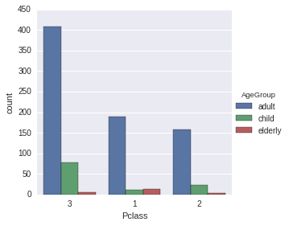

```python
sns.factorplot('Pclass', data=titanic_df, hue='AgeGroup', kind='count')
```

> I was surprised to see that there were more children in third class. My initial thoughts was that first and second class would have more children in it.

```python
titanic_df['AloneWithFam'] = titanic_df.SibSp + titanic_df.Parch
```

```python
titanic_df['AloneWithFam'].loc[titanic_df['AloneWithFam'] > 0] = 'With Family'

titanic_df['AloneWithFam'].loc[titanic_df['AloneWithFam'] == 0] = 'Alone'
```

```python
titanic_df.AloneWithFam.value_counts()
```

```
Alone          537
With Family    354
Name: AloneWithFam, dtype: int64
```

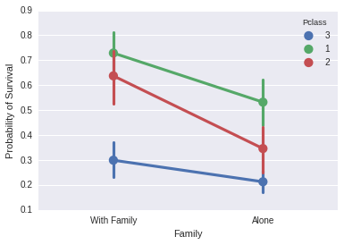

```python
p = sns.pointplot(x='AloneWithFam', y='Survived', hue='Pclass', data=titanic_df)
p.set(ylabel = 'Probability of Survival', xlabel = 'Family')
```

> I wanted to see whether or not class had something to do with the survival rate of those who had family with them against those who were alone. My initial toughts was that the higher class with a family member would be signicantly higher than those in third class.

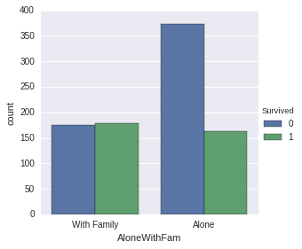

```python
sns.factorplot('AloneWithFam', data=titanic_df, hue='Survived', kind='count')
```

> Determining if a passenger was alone or not excludes cousins, nephews/nieces, aunts/uncles, and in-laws. Some children travelled only with a nanny, therefore parch=0 for them. As well, some travelled with very close friends or neighbors in a village, however, the definitions do not support such relations. Also mistresses and fiances were ignored. This mean that the numbers may or may not be off.